# Test a Perceptual Phenomenon

### Analyzing the Stroop Effect

Perform the analysis in the space below. Remember to follow [the instructions](https://docs.google.com/document/d/1-OkpZLjG_kX9J6LIQ5IltsqMzVWjh36QpnP2RYpVdPU/pub?embedded=True) and review the [project rubric](https://review.udacity.com/#!/rubrics/71/view) before submitting. Once you've completed the analysis and write up, download this file as a PDF or HTML file and submit in the next section.

(1) What is the independent variable? What is the dependent variable?

The independant variable is the color of the word The dependant variable is the timing it takes to identify the color

(2) What is an appropriate set of hypotheses for this task? What kind of statistical test do you expect to perform? Justify your choices.

H0 : μ = μ1 Null Hypothesis

H1 : μ < μ1 Alternative Hypothesis

μ is the mean of Congruent Data

μ1 is the mean of Incongruent Data

The null hypothesis: The population's average time to state the color of a word is not (statistically) different between congruent and incongruent data.

The hypothesis: The population's average time to state the color of the word is (statistically) significantly longer for incongruent data vs congruent data.

I expect to look at the different descriptive statistics, calculate the t-statistic, and see statistical significance. Since we are using the same 24 participants for both tests this would be a dependant T-Test. Because the stroop test is attempting to show that the conflicting color information can slow down a participants time this is a one tailed test hypothesizing that the incongruent (stroop) test is longer than the incongruent (normally colored) test for the 24 participants.

(3) Report some descriptive statistics regarding this dataset. Include at least one measure of central tendency and at least one measure of variability. The name of the data file is 'stroopdata.csv'.

```python
# Perform the analysis here

import pandas as pd
import io
import requests
import numpy as np
import scipy.stats as stats
import matplotlib.pyplot as plt
plt.style.use('ggplot')

df = pd.read_csv('stroopdata.csv')
```

The Congruent data has a range of (between max and min) 13.70 and Incongruent has 19.57

The Congruent data has a smaller standard deviation (Incongruent is about 35% larger standard deviation)

The Congruent data is more predictable and less widley distributed, perhaps because it is the way we are accustomed to reading

```python
df.describe()
```

|  | Congruent | Incongruent |
| --- | --- | --- |
| count | 24.000000 | 24.000000 |
| mean | 14.051125 | 22.015917 |
| std | 3.559358 | 4.797057 |
| min | 8.630000 | 15.687000 |
| 25% | 11.895250 | 18.716750 |
| 50% | 14.356500 | 21.017500 |
| 75% | 16.200750 | 24.051500 |
| max | 22.328000 | 35.255000 |

(4) Provide one or two visualizations that show the distribution of the sample data. Write one or two sentences noting what you observe about the plot or plots.

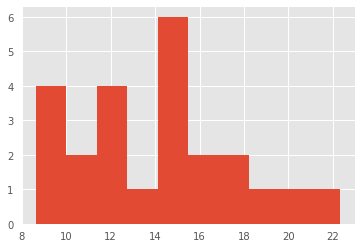

```python
# Build the visualizations here
plt.hist(df['Congruent'])
plt.show()
```

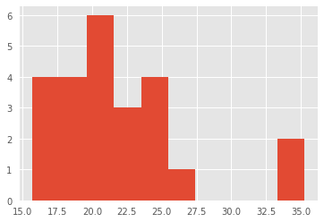

```python
plt.hist(df['Incongruent'])
plt.show()
```

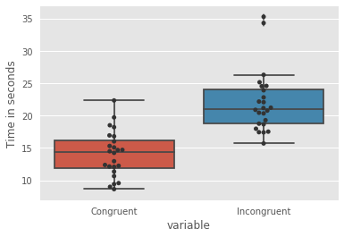

```python
dfmelt = pd.melt(df)
sns.boxplot(x='variable', y='value', data=dfmelt)
sns.swarmplot(x='variable', y='value', data=dfmelt, color="0.2")
plt.ylabel('Time in seconds')
plt.show()
```

(5) Now, perform the statistical test and report the results. What is the confidence level and your critical statistic value? Do you reject the null hypothesis or fail to reject it? Come to a conclusion in terms of the experiment task. Did the results match up with your expectations?

The T-Statistic is 8.0207 This is very far outside the confidence level of 0.05

With 23 Degrees of freedom (24 Sample Dependent Test)

1% Confidence level is 2.50

5% Confidence level is 1.714

And a Pvalue is less than 0.0001

[output not shown]

Note the P-value below with ttest_rel is for a two tailed test so it is not accurate, but we still have a very low pValue

```python
# Perform the statistical test here
stats.ttest_rel(df['Incongruent'],df['Congruent'])
```

```
Ttest_relResult(statistic=8.020706944109957, pvalue=4.1030005857111781e-08)
```

(6) Hypotheses regarding the reasons for the effect observed are presented.

An extension or related experiment to the performed Stroop task is provided, that may produce similar effects.

I hypothesize that the reason we have slower times for the Incongruent set is because we are given conflicting information. The color of the word and the actual color that the word is written in is different and confuses the test subjects.

Similar stroop-like could be conflicting picture to word stroop test. Perhaps navigating someone and saying left but pointing right (on a closed track). Anything where conflicting information is provided to test subjects and they are forced to choose between comprehending what reality is over an incorrect description or descriptive characteristic.